```python
import pandas as pd
import seaborn as sns
from sklearn.cluster import KMeans, AgglomerativeClustering
import matplotlib.pyplot as plt
from mpl_toolkits.mplot3d import Axes3D
```

# Task 1

## Dataset 1

```python
df_1=pd.read_csv('Data1.csv')
df_1
```

|  | Unnamed: 0 | X1 | X2 | X3 | Class |
| --- | --- | --- | --- | --- | --- |
| 0 | 1 | -0.063274 | 0.027734 | 0.022683 | 1 |
| 1 | 2 | -0.000731 | 0.048211 | 0.069198 | 1 |
| 2 | 3 | -0.060767 | -0.009080 | 0.053085 | 1 |
| 3 | 4 | 0.013252 | -0.011876 | 0.055324 | 1 |
| 4 | 5 | -0.054508 | -0.003813 | 0.001738 | 1 |
| ... | ... | ... | ... | ... | ... |
| 207 | 208 | 0.175738 | -0.053478 | -2.733752 | 7 |
| 208 | 209 | 0.396046 | -0.858377 | -3.126866 | 7 |
| 209 | 210 | -0.406362 | -0.334541 | -2.885598 | 7 |
| 210 | 211 | -0.299275 | 0.071281 | -3.642585 | 7 |
| 211 | 212 | -0.506192 | 0.433538 | -2.608597 | 7 |

212 rows × 5 columns

### Original Clusters

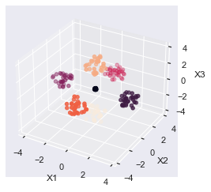

```python
sns.set(style = "darkgrid")

fig = plt.figure()
ax = fig.add_subplot(111, projection = '3d')

x = df_1['X1']
y = df_1['X2']
z = df_1['X3']
c=df_1['Class']

ax.set_xlabel("X1")
ax.set_ylabel("X2")
ax.set_zlabel("X3")

ax.scatter(x, y, z,c=c)

plt.show()
```

### K Means Cluster

```python
kmeans_1 = KMeans(n_clusters=7)
kmeans_1.fit(df_1.iloc[:,1:4])
```

```
KMeans(n_clusters=7)
```

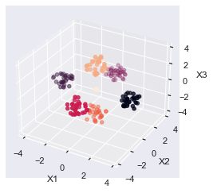

```python
#%matplotlib qt
sns.set(style = "darkgrid")

fig = plt.figure()
ax = fig.add_subplot(111, projection = '3d')

x = df_1['X1']
y = df_1['X2']
z = df_1['X3']

ax.set_xlabel("X1")
ax.set_ylabel("X2")
ax.set_zlabel("X3")

ax.scatter(x, y, z,c=kmeans_1.labels_)

plt.show()
```

### Hierarchical Cluster

```python
hierarchical_1 = AgglomerativeClustering(n_clusters=7).fit(df_1.iloc[:,1:4])
hierarchical_1.labels_
```

```
array([6, 6, 6, 6, 6, 6, 6, 6, 6, 6, 6, 6, 6, 6, 6, 6, 6, 6, 6, 6, 6, 6,
       6, 6, 6, 6, 6, 6, 6, 6, 6, 6, 4, 4, 4, 4, 4, 4, 4, 4, 4, 4, 4, 4,
       4, 4, 4, 4, 4, 4, 4, 4, 4, 4, 4, 4, 4, 4, 4, 4, 4, 4, 2, 2, 2, 2,
       2, 2, 2, 2, 2, 2, 2, 2, 2, 2, 2, 2, 2, 2, 2, 2, 2, 2, 2, 2, 2, 2,
       2, 2, 2, 2, 5, 5, 5, 5, 5, 5, 5, 5, 5, 5, 5, 5, 5, 5, 5, 5, 5, 5,
       5, 5, 5, 5, 5, 5, 5, 5, 5, 5, 5, 5, 1, 1, 1, 1, 1, 1, 1, 1, 1, 1,
       1, 1, 1, 1, 1, 1, 1, 1, 1, 1, 1, 1, 1, 1, 1, 1, 1, 1, 1, 1, 0, 0,
       0, 0, 0, 0, 0, 0, 0, 0, 0, 0, 0, 0, 0, 0, 0, 0, 0, 0, 0, 0, 0, 0,
       0, 0, 0, 0, 0, 0, 3, 3, 3, 3, 3, 3, 3, 3, 3, 3, 3, 3, 3, 3, 3, 3,
       3, 3, 3, 3, 3, 3, 3, 3, 3, 3, 3, 3, 3, 3], dtype=int64)
```

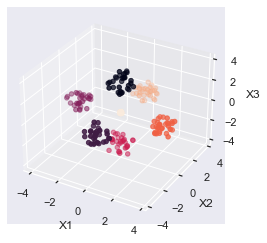

```python
sns.set(style = "darkgrid")

fig = plt.figure()
ax = fig.add_subplot(111, projection = '3d')

x = df_1['X1']
y = df_1['X2']
z = df_1['X3']

ax.set_xlabel("X1")
ax.set_ylabel("X2")
ax.set_zlabel("X3")

ax.scatter(x, y, z,c=hierarchical_1.labels_)

plt.show()
```

## Dataset 2

```python
df_2=pd.read_csv('Data2.csv')
df_2
```

|  | Unnamed: 0 | X | Y | C | Class |
| --- | --- | --- | --- | --- | --- |
| 0 | X1 | 3.277701 | 0.814082 | 0.326574 | 1 |
| 1 | X2 | 0.387577 | 0.176780 | 0.888046 | 1 |
| 2 | X3 | 0.268546 | 0.582963 | 0.080981 | 1 |
| 3 | X4 | 2.031145 | 0.244597 | 0.643921 | 1 |
| 4 | X5 | 0.188677 | 0.461280 | 0.496633 | 1 |
| ... | ... | ... | ... | ... | ... |
| 399 | X400 | 3.248655 | 2.297291 | 3.388138 | 3 |
| 400 | X | 4.100000 | 5.100000 | 0.504558 | 4 |
| 401 | X.1 | 3.900000 | 4.900000 | 0.941634 | 4 |
| 402 | X.2 | 4.000000 | 5.000000 | 0.702123 | 4 |
| 403 | X.3 | 4.100000 | 5.100000 | 0.887645 | 4 |

404 rows × 5 columns

### Original Clusters

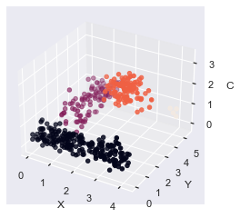

```python
sns.set(style = "darkgrid")

fig = plt.figure()
ax = fig.add_subplot(111, projection = '3d')

x = df_2['X']
y = df_2['Y']
z = df_2['C']
c=df_2['Class']

ax.set_xlabel("X")
ax.set_ylabel("Y")
ax.set_zlabel("C")

ax.scatter(x, y, z,c=c)

plt.show()
```

### K Means Cluster

```python
kmeans_2 = KMeans(n_clusters=4)
kmeans_2.fit(df_2.iloc[:,1:4])
```

```
KMeans(n_clusters=4)
```

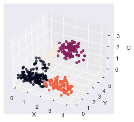

```python
#%matplotlib qt
sns.set(style = "darkgrid")

fig = plt.figure()
ax = fig.add_subplot(111, projection = '3d')

x = df_2['X']
y = df_2['Y']
z = df_2['C']
c=df_2['Class']

ax.set_xlabel("X")
ax.set_ylabel("Y")
ax.set_zlabel("C")

ax.scatter(x, y, z,c=kmeans_2.labels_)

plt.show()
```

### Hierarchical Cluster

```python
hierarchical_2 = AgglomerativeClustering(n_clusters=4).fit(df_2.iloc[:,1:4])
hierarchical_2.labels_
```

```
array([3, 1, 1, 1, 1, 3, 1, 3, 3, 1, 1, 3, 3, 1, 1, 3, 1, 1, 1, 1, 1, 3,
       1, 1, 1, 1, 3, 3, 3, 3, 3, 3, 1, 3, 1, 3, 1, 1, 3, 1, 3, 1, 1, 3,
       1, 1, 1, 3, 1, 1, 1, 1, 3, 1, 1, 3, 1, 1, 1, 1, 1, 1, 3, 1, 3, 1,
       1, 1, 1, 1, 1, 1, 1, 3, 1, 3, 3, 1, 1, 1, 1, 1, 1, 1, 3, 3, 3, 1,
       3, 1, 1, 3, 1, 1, 1, 3, 1, 1, 3, 3, 3, 1, 1, 3, 1, 3, 1, 1, 3, 3,
       1, 1, 1, 3, 1, 1, 1, 1, 1, 1, 3, 1, 1, 1, 3, 1, 1, 1, 1, 1, 1, 3,
       1, 1, 1, 1, 1, 3, 3, 3, 3, 1, 1, 3, 1, 1, 1, 3, 3, 1, 1, 3, 1, 1,
       1, 1, 1, 3, 1, 1, 1, 1, 1, 3, 3, 1, 3, 3, 3, 1, 1, 3, 1, 1, 3, 1,
       1, 3, 3, 1, 3, 3, 1, 3, 1, 3, 1, 1, 1, 1, 3, 3, 1, 1, 1, 3, 1, 1,
       1, 1, 0, 0, 0, 0, 0, 0, 0, 0, 0, 0, 0, 0, 0, 0, 0, 0, 0, 0, 0, 0,
       0, 0, 0, 0, 0, 0, 0, 0, 0, 0, 0, 0, 0, 0, 0, 0, 0, 0, 0, 0, 0, 0,
       0, 0, 0, 0, 0, 0, 0, 0, 0, 0, 0, 0, 0, 0, 0, 0, 0, 0, 0, 0, 0, 0,
       0, 0, 0, 0, 0, 0, 0, 0, 0, 0, 0, 0, 0, 0, 0, 0, 0, 0, 0, 0, 0, 0,
       0, 0, 0, 0, 0, 0, 0, 0, 0, 0, 0, 0, 0, 0, 2, 2, 2, 2, 2, 2, 2, 2,
       2, 2, 2, 2, 2, 2, 2, 2, 2, 2, 2, 2, 2, 2, 2, 2, 2, 2, 2, 2, 2, 2,
       2, 2, 2, 2, 2, 2, 2, 2, 2, 2, 2, 2, 2, 2, 2, 2, 2, 2, 2, 2, 2, 2,
       2, 2, 2, 2, 2, 2, 2, 2, 2, 2, 2, 2, 2, 2, 2, 2, 2, 2, 2, 2, 2, 2,
       2, 2, 2, 2, 2, 2, 2, 2, 2, 2, 2, 2, 2, 2, 2, 2, 2, 2, 2, 2, 2, 2,
       2, 2, 2, 2, 0, 0, 0, 0], dtype=int64)
```

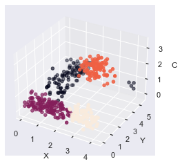

```python
sns.set(style = "darkgrid")

fig = plt.figure()
ax = fig.add_subplot(111, projection = '3d')

x = df_2['X']
y = df_2['Y']
z = df_2['C']
c=df_2['Class']

ax.set_xlabel("X")
ax.set_ylabel("Y")
ax.set_zlabel("C")

ax.scatter(x, y, z,c=hierarchical_2.labels_)

plt.show()
```

## Dataset 3

```python
df_3=pd.read_csv('Data3.csv')
df_3
```

|  | Unnamed: 0 | X1 | X2 | X3 | Class |
| --- | --- | --- | --- | --- | --- |
| 0 | 1 | 1.295428 | 0.050829 | -0.385217 | 1 |
| 1 | 2 | 1.409178 | -0.035191 | -0.251980 | 1 |
| 2 | 3 | 1.096803 | 0.246365 | -0.415011 | 1 |
| 3 | 4 | 1.463328 | 0.265354 | -0.513488 | 1 |
| 4 | 5 | 1.603284 | 0.080577 | -0.470257 | 1 |
| ... | ... | ... | ... | ... | ... |
| 395 | 396 | 0.795695 | 0.209456 | 1.880609 | 4 |
| 396 | 397 | 0.653127 | -0.703156 | 1.549448 | 4 |
| 397 | 398 | -0.726249 | -0.103244 | 0.694300 | 4 |
| 398 | 399 | 0.808596 | -0.492640 | 1.649370 | 4 |
| 399 | 400 | 0.749291 | -0.447840 | 0.863555 | 4 |

400 rows × 5 columns

### Original Clusters

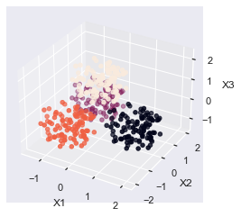

```python
sns.set(style = "darkgrid")

fig = plt.figure()
ax = fig.add_subplot(111, projection = '3d')

x = df_3['X1']
y = df_3['X2']
z = df_3['X3']
c=df_3['Class']

ax.set_xlabel("X1")
ax.set_ylabel("X2")
ax.set_zlabel("X3")

ax.scatter(x, y, z,c=c)

plt.show()
```

### K Means Cluster

```python
kmeans_3 = KMeans(n_clusters=4)
kmeans_3.fit(df_3.iloc[:,1:4])
```

```
KMeans(n_clusters=4)
```

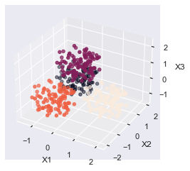

```python
sns.set(style = "darkgrid")

fig = plt.figure()
ax = fig.add_subplot(111, projection = '3d')

x = df_3['X1']
y = df_3['X2']
z = df_3['X3']
c=df_3['Class']

ax.set_xlabel("X1")
ax.set_ylabel("X2")
ax.set_zlabel("X3")

ax.scatter(x, y, z,c=kmeans_3.labels_)

plt.show()
```

### Hierarchical Cluster

```python
hierarchical_3 = AgglomerativeClustering(n_clusters=4).fit(df_3.iloc[:,1:4])
hierarchical_3.labels_
```

```
array([1, 1, 1, 1, 1, 1, 1, 1, 1, 1, 1, 1, 1, 1, 1, 1, 1, 1, 1, 1, 1, 1,
       1, 1, 1, 1, 1, 1, 1, 1, 1, 1, 1, 1, 1, 1, 1, 1, 1, 1, 1, 1, 1, 1,
       1, 1, 1, 1, 1, 1, 1, 1, 1, 1, 1, 1, 1, 1, 1, 1, 1, 1, 1, 1, 1, 1,
       1, 1, 1, 1, 1, 1, 1, 1, 1, 1, 1, 1, 1, 1, 1, 1, 1, 1, 1, 1, 1, 1,
       1, 1, 1, 1, 1, 1, 1, 1, 1, 1, 1, 1, 3, 3, 3, 3, 3, 3, 3, 3, 3, 3,
       3, 3, 3, 3, 3, 3, 3, 3, 3, 3, 3, 3, 3, 3, 3, 3, 3, 3, 3, 3, 3, 3,
       3, 3, 3, 3, 3, 3, 3, 3, 3, 3, 3, 3, 3, 3, 3, 3, 3, 0, 3, 3, 3, 3,
       3, 3, 3, 3, 3, 0, 3, 3, 3, 0, 3, 3, 3, 0, 3, 3, 3, 3, 3, 3, 3, 3,
       3, 3, 3, 3, 3, 3, 3, 3, 3, 3, 3, 3, 3, 3, 3, 3, 3, 3, 0, 3, 3, 3,
       3, 3, 0, 0, 0, 0, 0, 0, 0, 0, 0, 0, 0, 0, 0, 0, 0, 0, 0, 0, 0, 0,
       0, 0, 0, 0, 0, 0, 0, 0, 0, 0, 0, 0, 0, 0, 0, 0, 0, 0, 0, 0, 0, 0,
       0, 0, 0, 0, 0, 0, 0, 0, 0, 0, 0, 0, 0, 0, 0, 0, 0, 0, 0, 0, 0, 0,
       0, 0, 0, 0, 0, 0, 0, 0, 0, 0, 0, 0, 0, 0, 0, 0, 0, 0, 0, 0, 0, 0,
       0, 0, 0, 0, 0, 0, 0, 0, 0, 0, 0, 0, 0, 0, 2, 2, 2, 2, 2, 2, 2, 2,
       2, 2, 2, 2, 2, 2, 2, 2, 2, 2, 2, 2, 2, 2, 2, 2, 2, 2, 2, 2, 2, 2,
       2, 2, 2, 2, 2, 2, 2, 2, 2, 2, 2, 2, 2, 2, 2, 2, 2, 2, 2, 2, 2, 2,
       2, 2, 2, 2, 2, 2, 2, 2, 2, 2, 2, 2, 2, 2, 2, 2, 2, 2, 2, 2, 2, 2,
       2, 2, 2, 2, 2, 2, 2, 2, 2, 2, 2, 2, 2, 2, 2, 2, 2, 2, 2, 2, 2, 2,
       2, 2, 2, 2], dtype=int64)
```

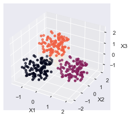

```python
sns.set(style = "darkgrid")

fig = plt.figure()
ax = fig.add_subplot(111, projection = '3d')

x = df_3['X1']
y = df_3['X2']
z = df_3['X3']

ax.set_xlabel("X1")
ax.set_ylabel("X2")
ax.set_zlabel("X3")

ax.scatter(x, y, z,c=hierarchical_3.labels_)

plt.show()
```

## Dataset 4

```python
df_4=pd.read_csv('Data4.csv')
df_4
```

|  | Unnamed: 0 | X1 | X2 | X3 | Class |
| --- | --- | --- | --- | --- | --- |
| 0 | 1 | -0.45300 | -0.8910 | 0.02300 | 1 |
| 1 | 2 | 0.65300 | -0.8460 | 0.02110 | 1 |
| 2 | 3 | 0.39800 | 0.9130 | -0.00139 | 1 |
| 3 | 4 | 0.09520 | 1.0500 | 0.00628 | 1 |
| 4 | 5 | 0.52400 | -0.9410 | 0.03780 | 1 |
| ... | ... | ... | ... | ... | ... |
| 995 | 996 | 0.01520 | 0.0531 | -0.36100 | 2 |
| 996 | 997 | 0.05160 | 0.6910 | 0.87500 | 2 |
| 997 | 998 | -0.00511 | 1.3900 | -0.94700 | 2 |
| 998 | 999 | -0.06710 | 0.7140 | 0.88100 | 2 |
| 999 | 1000 | -0.05770 | 0.4280 | -0.73000 | 2 |

1000 rows × 5 columns

### Original Clusters

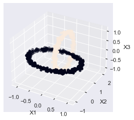

```python
sns.set(style = "darkgrid")

fig = plt.figure()
ax = fig.add_subplot(111, projection = '3d')

x = df_4['X1']
y = df_4['X2']
z = df_4['X3']
c=df_4['Class']

ax.set_xlabel("X1")
ax.set_ylabel("X2")
ax.set_zlabel("X3")

ax.scatter(x, y, z,c=c)

plt.show()
```

### K Means Cluster

```python
kmeans_4 = KMeans(n_clusters=2)
kmeans_4.fit(df_4.iloc[:,1:4])
```

```
KMeans(n_clusters=2)
```

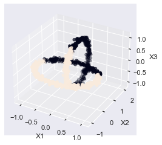

```python
sns.set(style = "darkgrid")

fig = plt.figure()
ax = fig.add_subplot(111, projection = '3d')

x = df_4['X1']
y = df_4['X2']
z = df_4['X3']
c=df_4['Class']

ax.set_xlabel("X1")
ax.set_ylabel("X2")
ax.set_zlabel("X3")

ax.scatter(x, y, z,c=kmeans_4.labels_)

plt.show()
```

### Hierarchical Cluster

```python
hierarchical_4 = AgglomerativeClustering(n_clusters=2).fit(df_4.iloc[:,1:4])
hierarchical_4.labels_
```

```
array([1, 1, 0, 0, 1, 0, 0, 1, 1, 1, 0, 1, 0, 0, 1, 0, 1, 0, 0, 1, 1, 1,
       0, 1, 1, 0, 1, 0, 1, 1, 0, 0, 1, 1, 0, 0, 0, 1, 0, 1, 0, 0, 1, 1,
       0, 0, 1, 1, 0, 1, 1, 1, 1, 1, 1, 1, 1, 1, 0, 1, 1, 0, 0, 0, 1, 1,
       1, 0, 0, 1, 0, 0, 1, 1, 0, 0, 0, 0, 1, 0, 0, 0, 1, 1, 1, 1, 1, 0,
       1, 1, 1, 0, 0, 1, 0, 0, 1, 1, 1, 1, 1, 0, 0, 1, 1, 0, 0, 1, 0, 1,
       0, 0, 1, 1, 0, 0, 1, 1, 1, 0, 0, 0, 1, 0, 0, 1, 1, 1, 1, 0, 1, 1,
       1, 1, 1, 1, 0, 0, 1, 1, 0, 0, 1, 1, 0, 1, 0, 0, 1, 1, 0, 1, 0, 1,
       0, 0, 1, 0, 1, 1, 0, 1, 0, 1, 1, 1, 0, 1, 1, 0, 1, 1, 1, 0, 0, 1,
       1, 1, 1, 1, 1, 1, 1, 1, 0, 1, 1, 0, 1, 1, 1, 1, 0, 1, 0, 1, 1, 1,
       0, 1, 1, 1, 0, 0, 1, 0, 0, 0, 1, 1, 1, 1, 1, 1, 0, 1, 0, 1, 0, 0,
       1, 1, 0, 0, 1, 1, 1, 1, 1, 1, 0, 1, 1, 1, 1, 1, 0, 1, 0, 1, 1, 0,
       1, 0, 1, 1, 0, 0, 0, 1, 1, 0, 0, 0, 0, 1, 0, 1, 1, 0, 0, 1, 1, 1,
       1, 1, 1, 0, 0, 1, 1, 0, 0, 0, 1, 0, 1, 0, 0, 1, 1, 0, 0, 0, 0, 1,
       0, 1, 0, 1, 1, 1, 1, 0, 1, 1, 1, 0, 1, 0, 1, 1, 0, 1, 0, 1, 1, 1,
       1, 1, 0, 1, 1, 1, 0, 0, 1, 1, 1, 0, 1, 1, 1, 0, 0, 0, 0, 0, 1, 1,
```

[output cut: 31 more lines]

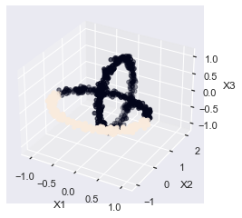

```python
sns.set(style = "darkgrid")

fig = plt.figure()
ax = fig.add_subplot(111, projection = '3d')

x = df_4['X1']
y = df_4['X2']
z = df_4['X3']

ax.set_xlabel("X1")
ax.set_ylabel("X2")
ax.set_zlabel("X3")

ax.scatter(x, y, z,c=hierarchical_4.labels_)

plt.show()
```

## Dataset 5

```python
df_5=pd.read_csv('Data5.csv')
df_5
```

|  | Unnamed: 0 | X1 | X2 | X3 | Class |
| --- | --- | --- | --- | --- | --- |
| 0 | 1 | -4.822490 | -50.402170 | 4.020861 | 1 |
| 1 | 2 | -44.460120 | 20.964670 | -11.492060 | 1 |
| 2 | 3 | 50.001020 | 0.780748 | 9.134460 | 1 |
| 3 | 4 | -41.699080 | -22.310060 | 16.314120 | 1 |
| 4 | 5 | 4.425242 | -4.666664 | 50.223740 | 1 |
| ... | ... | ... | ... | ... | ... |
| 795 | 796 | -1.531027 | 0.681636 | 0.543271 | 2 |
| 796 | 797 | 0.500754 | -1.848209 | 0.605654 | 2 |
| 797 | 798 | 1.089574 | -0.246493 | -3.355758 | 2 |
| 798 | 799 | -1.907717 | 4.964502 | 2.098423 | 2 |
| 799 | 800 | 3.415463 | 4.529521 | -1.617736 | 2 |

800 rows × 5 columns

### Original Clusters

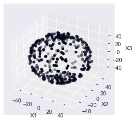

```python
sns.set(style = "darkgrid")

fig = plt.figure()
ax = fig.add_subplot(111, projection = '3d')

x = df_5['X1']
y = df_5['X2']
z = df_5['X3']
c=df_5['Class']

ax.set_xlabel("X1")
ax.set_ylabel("X2")
ax.set_zlabel("X3")

ax.scatter(x, y, z,c=c)

plt.show()
```

### K Means Cluster

```python
kmeans_5 = KMeans(n_clusters=2)
kmeans_5.fit(df_5.iloc[:,1:4])
```

```
KMeans(n_clusters=2)
```

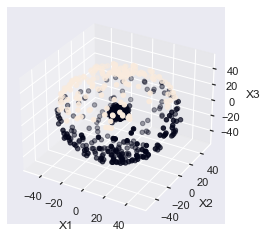

```python
sns.set(style = "darkgrid")

fig = plt.figure()
ax = fig.add_subplot(111, projection = '3d')

x = df_5['X1']
y = df_5['X2']
z = df_5['X3']
c=df_5['Class']

ax.set_xlabel("X1")
ax.set_ylabel("X2")
ax.set_zlabel("X3")

ax.scatter(x, y, z,c=kmeans_5.labels_)

plt.show()
```

### Hierarchical Cluster

```python
hierarchical_5 = AgglomerativeClustering(n_clusters=2).fit(df_5.iloc[:,1:4])
hierarchical_5.labels_
```

```
array([1, 0, 0, 0, 0, 0, 0, 0, 0, 0, 0, 0, 1, 0, 0, 0, 0, 0, 0, 1, 1, 0,
       0, 1, 0, 0, 0, 0, 0, 1, 0, 0, 0, 0, 0, 0, 1, 0, 0, 0, 0, 0, 0, 1,
       1, 0, 0, 1, 0, 0, 1, 1, 0, 1, 0, 1, 1, 1, 0, 0, 0, 0, 0, 1, 1, 0,
       0, 1, 0, 1, 0, 0, 1, 0, 0, 1, 0, 1, 0, 1, 0, 0, 1, 0, 0, 0, 0, 0,
       1, 0, 0, 0, 0, 0, 0, 0, 0, 1, 0, 0, 0, 0, 1, 0, 0, 0, 0, 0, 0, 0,
       0, 0, 1, 0, 1, 1, 0, 0, 0, 0, 0, 0, 0, 0, 0, 0, 0, 0, 0, 0, 0, 0,
       0, 0, 1, 0, 0, 1, 0, 0, 1, 0, 0, 1, 1, 1, 0, 0, 0, 1, 1, 0, 1, 1,
       1, 0, 0, 1, 0, 1, 1, 0, 0, 1, 1, 0, 0, 0, 1, 0, 0, 0, 0, 0, 1, 0,
       0, 1, 0, 1, 0, 0, 1, 0, 0, 0, 0, 0, 0, 1, 0, 0, 0, 0, 0, 0, 1, 0,
       1, 1, 1, 0, 0, 1, 1, 1, 0, 0, 1, 0, 1, 0, 0, 0, 0, 1, 1, 0, 0, 0,
       1, 0, 0, 1, 0, 0, 1, 0, 1, 0, 0, 0, 0, 0, 0, 0, 1, 1, 0, 1, 0, 0,
       0, 1, 0, 1, 0, 1, 0, 0, 0, 0, 0, 1, 0, 0, 0, 0, 0, 0, 1, 1, 1, 1,
       1, 1, 1, 0, 0, 0, 0, 1, 0, 0, 0, 1, 1, 0, 0, 1, 1, 1, 0, 1, 1, 0,
       0, 0, 0, 0, 0, 0, 0, 1, 0, 0, 0, 1, 1, 0, 0, 1, 1, 0, 1, 1, 1, 0,
       1, 0, 0, 1, 0, 0, 0, 0, 0, 0, 1, 0, 1, 0, 0, 0, 0, 1, 0, 0, 0, 0,
```

[output cut: 22 more lines]

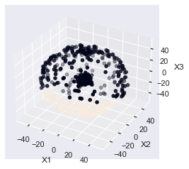

```python
sns.set(style = "darkgrid")

fig = plt.figure()
ax = fig.add_subplot(111, projection = '3d')

x = df_5['X1']
y = df_5['X2']
z = df_5['X3']

ax.set_xlabel("X1")
ax.set_ylabel("X2")
ax.set_zlabel("X3")

ax.scatter(x, y, z,c=hierarchical_5.labels_)

plt.show()
```

## Dataset 6

```python
df_6=pd.read_csv('Data6.csv')
df_6
```

|  | Unnamed: 0 | X1 | X2 | Class |
| --- | --- | --- | --- | --- |
| 0 | 1 | 1.388261 | 2.076096 | 1 |
| 1 | 2 | 2.177247 | 3.102304 | 1 |
| 2 | 3 | 0.378645 | 5.307610 | 1 |
| 3 | 4 | 3.681732 | 1.622681 | 1 |
| 4 | 5 | 2.462861 | 2.777897 | 1 |
| ... | ... | ... | ... | ... |
| 4091 | 4092 | 0.909687 | 0.375763 | 2 |
| 4092 | 4093 | 2.698381 | 0.511262 | 2 |
| 4093 | 4094 | 1.078797 | 1.526153 | 2 |
| 4094 | 4095 | 1.974889 | -0.649343 | 2 |
| 4095 | 4096 | -0.127192 | -0.763974 | 2 |

4096 rows × 4 columns

### Original Clusters

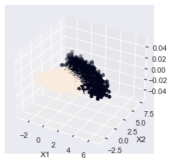

```python
sns.set(style = "darkgrid")

fig = plt.figure()
ax = fig.add_subplot(111, projection = '3d')

x = df_6['X1']
y = df_6['X2']
c=df_6['Class']

ax.set_xlabel("X1")
ax.set_ylabel("X2")

ax.scatter(x, y, c=c)

plt.show()
```

### K Means Cluster

```python
kmeans_6 = KMeans(n_clusters=2)
kmeans_6.fit(df_6.iloc[:,1:3])
```

```
KMeans(n_clusters=2)
```

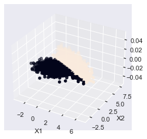

```python
sns.set(style = "darkgrid")

fig = plt.figure()
ax = fig.add_subplot(111, projection = '3d')

x = df_6['X1']
y = df_6['X2']
c=df_6['Class']

ax.set_xlabel("X1")
ax.set_ylabel("X2")

ax.scatter(x, y, c=kmeans_6.labels_)

plt.show()
```

### Hierarchical Cluster

```python
hierarchical_6 = AgglomerativeClustering(n_clusters=2).fit(df_6.iloc[:,1:3])
hierarchical_6.labels_
```

```
array([0, 0, 0, ..., 1, 1, 1], dtype=int64)
```

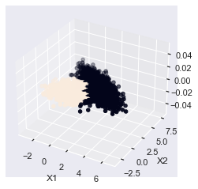

```python
sns.set(style = "darkgrid")

fig = plt.figure()
ax = fig.add_subplot(111, projection = '3d')

x = df_6['X1']
y = df_6['X2']
c=df_6['Class']

ax.set_xlabel("X1")
ax.set_ylabel("X2")

ax.scatter(x, y, c=hierarchical_6.labels_)

plt.show()
```

## Dataset 7

```python
df_7=pd.read_csv('Data7.csv')
df_7
```

|  | Unnamed: 0 | X1 | X2 | Class |
| --- | --- | --- | --- | --- |
| 0 | 1 | -3.000000 | -3.000000 | 5 |
| 1 | 2 | -3.000000 | 3.000000 | 4 |
| 2 | 3 | 3.000000 | -3.000000 | 6 |
| 3 | 4 | 3.000000 | 3.000000 | 3 |
| 4 | 5 | -0.417091 | 0.114782 | 1 |
| ... | ... | ... | ... | ... |
| 765 | 766 | -1.604434 | -1.118861 | 2 |
| 766 | 767 | -3.050000 | -3.050000 | 5 |
| 767 | 768 | -3.050000 | 2.950000 | 4 |
| 768 | 769 | 2.950000 | -3.050000 | 6 |
| 769 | 770 | 2.950000 | 2.950000 | 3 |

770 rows × 4 columns

### Original Clusters

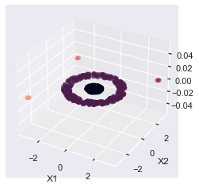

```python
sns.set(style = "darkgrid")

fig = plt.figure()
ax = fig.add_subplot(111, projection = '3d')

x = df_7['X1']
y = df_7['X2']
c=df_7['Class']

ax.set_xlabel("X1")
ax.set_ylabel("X2")

ax.scatter(x, y, c=c)

plt.show()
```

### K Means Cluster

```python
kmeans_7 = KMeans(n_clusters=6)
kmeans_7.fit(df_7.iloc[:,1:3])
```

```
KMeans(n_clusters=6)
```

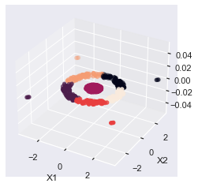

```python
sns.set(style = "darkgrid")

fig = plt.figure()
ax = fig.add_subplot(111, projection = '3d')

x = df_7['X1']
y = df_7['X2']
c=df_7['Class']

ax.set_xlabel("X1")
ax.set_ylabel("X2")

ax.scatter(x, y, c=kmeans_7.labels_)

plt.show()
```

### Hierarchical Cluster

```python
hierarchical_7 = AgglomerativeClustering(n_clusters=6).fit(df_7.iloc[:,1:3])
hierarchical_7.labels_
```

```
array([2, 3, 0, 1, 4, 4, 4, 4, 4, 4, 4, 4, 4, 4, 4, 4, 4, 4, 4, 4, 4, 4,
       4, 4, 4, 4, 4, 4, 4, 4, 4, 4, 4, 4, 4, 4, 4, 4, 4, 4, 4, 4, 4, 4,
       4, 4, 4, 4, 4, 4, 4, 4, 4, 4, 4, 4, 4, 4, 4, 4, 4, 4, 4, 4, 4, 4,
       4, 4, 4, 4, 4, 4, 4, 4, 4, 4, 4, 4, 4, 4, 4, 4, 4, 4, 4, 4, 4, 4,
       4, 4, 4, 4, 4, 4, 4, 4, 4, 4, 4, 4, 4, 4, 4, 4, 4, 4, 4, 4, 4, 4,
       4, 4, 4, 4, 4, 4, 4, 4, 4, 4, 4, 4, 4, 4, 4, 4, 4, 4, 4, 4, 4, 4,
       4, 4, 4, 4, 4, 4, 4, 4, 4, 4, 4, 4, 4, 4, 4, 4, 4, 4, 4, 4, 4, 4,
       4, 4, 4, 4, 4, 4, 4, 4, 4, 4, 4, 4, 4, 4, 4, 4, 4, 4, 4, 4, 4, 4,
       4, 4, 4, 4, 4, 4, 4, 4, 4, 4, 4, 4, 4, 4, 4, 4, 4, 4, 4, 4, 4, 4,
       4, 4, 4, 4, 4, 4, 4, 4, 4, 4, 4, 4, 4, 4, 4, 4, 4, 4, 4, 4, 4, 4,
       4, 4, 4, 4, 4, 4, 4, 4, 4, 4, 4, 4, 4, 4, 4, 4, 4, 4, 4, 4, 4, 4,
       4, 4, 4, 4, 4, 4, 4, 4, 4, 4, 4, 4, 4, 4, 4, 4, 4, 4, 4, 4, 4, 4,
       4, 4, 4, 4, 4, 4, 4, 4, 4, 4, 4, 4, 4, 4, 4, 4, 4, 4, 4, 4, 4, 4,
       4, 4, 4, 4, 4, 4, 4, 4, 4, 4, 4, 4, 4, 4, 4, 4, 4, 4, 4, 4, 4, 4,
       4, 4, 4, 4, 4, 4, 4, 4, 4, 4, 4, 4, 4, 4, 4, 4, 4, 4, 4, 4, 4, 4,
```

[output cut: 21 more lines]

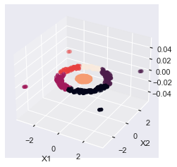

```python
sns.set(style = "darkgrid")

fig = plt.figure()
ax = fig.add_subplot(111, projection = '3d')

x = df_7['X1']
y = df_7['X2']
c=df_7['Class']

ax.set_xlabel("X1")
ax.set_ylabel("X2")

ax.scatter(x, y, c=hierarchical_7.labels_)

plt.show()
```

## Dataset 8

```python
df_8=pd.read_csv('Data8.csv')
df_8
```

|  | Unnamed: 0 | X1 | X2 | X3 | Class |
| --- | --- | --- | --- | --- | --- |
| 0 | 1 | 0.000000 | 0.000000 | 1.00000 | 1 |
| 1 | 2 | 0.000000 | 0.052336 | 0.99863 | 1 |
| 2 | 3 | 0.049774 | 0.016173 | 0.99863 | 1 |
| 3 | 4 | 0.030762 | -0.042341 | 0.99863 | 1 |
| 4 | 5 | -0.030762 | -0.042341 | 0.99863 | 1 |
| ... | ... | ... | ... | ... | ... |
| 3997 | 3998 | 0.049774 | -0.016173 | -0.99863 | 1 |
| 3998 | 3999 | 0.000000 | -0.052336 | -0.99863 | 1 |
| 3999 | 4000 | -0.049774 | -0.016173 | -0.99863 | 1 |
| 4000 | 4001 | -0.030762 | 0.042341 | -0.99863 | 1 |
| 4001 | 4002 | 0.000000 | 0.000000 | -1.00000 | 1 |

4002 rows × 5 columns

### Original Clusters

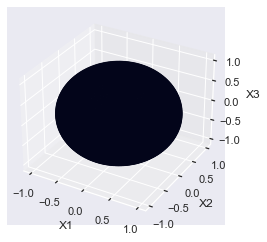

```python
sns.set(style = "darkgrid")

fig = plt.figure()
ax = fig.add_subplot(111, projection = '3d')

x = df_8['X1']
y = df_8['X2']
z = df_8['X3']
c=df_8['Class']

ax.set_xlabel("X1")
ax.set_ylabel("X2")
ax.set_zlabel("X3")

ax.scatter(x, y,z, c=c)

plt.show()
```

### K Means Cluster

```python
kmeans_8 = KMeans(n_clusters=1)
kmeans_8.fit(df_8.iloc[:,1:4])
```

```
KMeans(n_clusters=1)
```

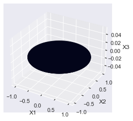

```python
sns.set(style = "darkgrid")

fig = plt.figure()
ax = fig.add_subplot(111, projection = '3d')

x = df_8['X1']
y = df_8['X2']
z = df_8['X3']
c=df_8['Class']

ax.set_xlabel("X1")
ax.set_ylabel("X2")
ax.set_zlabel("X3")

ax.scatter(x, y, c=kmeans_8.labels_)

plt.show()
```

### Hierarchical Cluster

```python
hierarchical_8 = AgglomerativeClustering(n_clusters=1).fit(df_8.iloc[:,1:4])
hierarchical_8.labels_
```

```
array([0, 0, 0, ..., 0, 0, 0], dtype=int64)
```

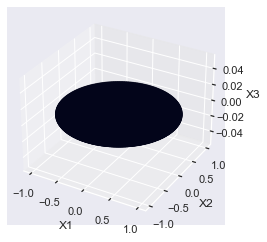

```python
sns.set(style = "darkgrid")

fig = plt.figure()
ax = fig.add_subplot(111, projection = '3d')

x = df_8['X1']
y = df_8['X2']
z = df_8['X3']
c=df_8['Class']

ax.set_xlabel("X1")
ax.set_ylabel("X2")
ax.set_zlabel("X3")

ax.scatter(x, y, c=hierarchical_8.labels_)

plt.show()
```

# Task 2

```python
from google.colab import files
uploaded = files.upload()
```

Upload widget is only available when the cell has been executed in the current browser session. Please rerun this cell to enable.

```
Saving World Indicators.csv to World Indicators.csv
```

**Importing required libraries**

```python
import pandas as pd
import numpy as np
from sklearn.preprocessing import MinMaxScaler
import seaborn as sns
import matplotlib.pyplot as plt
from sklearn.cluster import KMeans
from sklearn.cluster import AgglomerativeClustering
from sklearn.metrics import silhouette_score
from sklearn import metrics
```

Reading the data

```python
world_df=pd.read_csv('World Indicators.csv')
```

**Checking shape**

```python
world_df.shape
```

```
(208, 20)
```

**Checking for missing values**

```python
world_df.isnull().sum()
```

```
Birth Rate                 9
Business Tax Rate         27
Days to Start Business    27
Energy Usage              72
GDP                       20
Health Exp % GDP          23
Health Exp/Capita         23
Hours to do Tax           28
Infant Mortality Rate     20
Internet Usage             9
Lending Interest          77
Life Expectancy Female    11
Life Expectancy Male      11
Mobile Phone Usage        12
Population 0-14           17
Population 15-64          17
Population 65+            17
Population Urban           2
Region                     0
Country                    0
dtype: int64
```

**Dropping columns with many missing vaues**

```python
world_df=world_df.drop(['Energy Usage','Lending Interest'],axis=1)
```

**Dropping rows with missing values**

```python
world_df.dropna(how='any',inplace=True)
```

```python
world_df.isnull().sum()
```

```
Birth Rate                0
Business Tax Rate         0
Days to Start Business    0
GDP                       0
Health Exp % GDP          0
Health Exp/Capita         0
Hours to do Tax           0
Infant Mortality Rate     0
Internet Usage            0
Life Expectancy Female    0
Life Expectancy Male      0
Mobile Phone Usage        0
Population 0-14           0
Population 15-64          0
Population 65+            0
Population Urban          0
Region                    0
Country                   0
dtype: int64
```

```python
world_df.shape
```

```
(171, 18)
```

**Checking the data types of columns**

```python
world_df.dtypes
```

```
Birth Rate                float64
Business Tax Rate          object
Days to Start Business    float64
GDP                        object
Health Exp % GDP          float64
Health Exp/Capita          object
Hours to do Tax           float64
Infant Mortality Rate     float64
Internet Usage            float64
Life Expectancy Female    float64
Life Expectancy Male      float64
Mobile Phone Usage        float64
Population 0-14           float64
Population 15-64          float64
Population 65+            float64
Population Urban          float64
Region                     object
Country                    object
dtype: object
```

**Converting object into float data type**

```python
world_df['Business Tax Rate'] = world_df['Business Tax Rate'].str.rstrip('%').astype('float')/100
world_df['GDP'] = world_df['GDP'].str.replace('$','')
world_df['Health Exp/Capita'] = world_df['Health Exp/Capita'].str.replace('$','')
world_df['GDP'] = world_df['GDP'].str.replace(',','')
world_df['Health Exp/Capita'] = world_df['Health Exp/Capita'].str.replace(',','')
```

```python
world_df.dtypes
```

```
Birth Rate                float64
Business Tax Rate         float64
Days to Start Business    float64
GDP                        object
Health Exp % GDP          float64
Health Exp/Capita          object
Hours to do Tax           float64
Infant Mortality Rate     float64
Internet Usage            float64
Life Expectancy Female    float64
Life Expectancy Male      float64
Mobile Phone Usage        float64
Population 0-14           float64
Population 15-64          float64
Population 65+            float64
Population Urban          float64
Region                     object
Country                    object
dtype: object
```

```python
world_df = world_df.astype({'GDP':'float'})
world_df = world_df.astype({'Health Exp/Capita':'float'})
```

```python
world_df.dtypes
```

```
Birth Rate                float64
Business Tax Rate         float64
Days to Start Business    float64
GDP                       float64
Health Exp % GDP          float64
Health Exp/Capita         float64
Hours to do Tax           float64
Infant Mortality Rate     float64
Internet Usage            float64
Life Expectancy Female    float64
Life Expectancy Male      float64
Mobile Phone Usage        float64
Population 0-14           float64
Population 15-64          float64
Population 65+            float64
Population Urban          float64
Region                     object
Country                    object
dtype: object
```

```python
world_df.head()
```

|  | Birth Rate | Business Tax Rate | Days to Start Business | GDP | Health Exp % GDP | Health Exp/Capita | Hours to do Tax | Infant Mortality Rate | Internet Usage | Life Expectancy Female | Life Expectancy Male | Mobile Phone Usage | Population 0-14 | Population 15-64 | Population 65+ | Population Urban | Region | Country |
| --- | --- | --- | --- | --- | --- | --- | --- | --- | --- | --- | --- | --- | --- | --- | --- | --- | --- | --- |
| 0 | 0.025 | 0.720 | 25.0 | 1.990709e+11 | 0.044 | 233.0 | 451.0 | 0.023 | 0.1 | 72.0 | 69.0 | 0.9 | 0.272 | 0.681 | 0.047 | 0.682 | Africa | Algeria |
| 1 | 0.046 | 0.521 | 66.0 | 1.041159e+11 | 0.034 | 178.0 | 282.0 | 0.107 | 0.1 | 53.0 | 50.0 | 0.5 | 0.477 | 0.499 | 0.024 | 0.409 | Africa | Angola |
| 2 | 0.037 | 0.659 | 29.0 | 7.294900e+09 | 0.045 | 34.0 | 270.0 | 0.060 | 0.0 | 60.0 | 58.0 | 0.8 | 0.432 | 0.539 | 0.029 | 0.423 | Africa | Benin |
| 3 | 0.024 | 0.195 | 60.0 | 1.529242e+10 | 0.052 | 404.0 | 152.0 | 0.039 | 0.1 | 46.0 | 47.0 | 1.5 | 0.340 | 0.625 | 0.035 | 0.565 | Africa | Botswana |
| 4 | 0.042 | 0.435 | 13.0 | 1.039576e+10 | 0.064 | 39.0 | 270.0 | 0.068 | 0.0 | 56.0 | 55.0 | 0.5 | 0.458 | 0.517 | 0.025 | 0.265 | Africa | Burkina Faso |

**Data Scaling**

```python
scaler=MinMaxScaler()
world_df.iloc[:,0:16]=scaler.fit_transform(world_df.iloc[:,0:16])
world_df=pd.DataFrame(world_df)
```

```python
world_df.head()
```

|  | Birth Rate | Business Tax Rate | Days to Start Business | GDP | Health Exp % GDP | Health Exp/Capita | Hours to do Tax | Infant Mortality Rate | Internet Usage | Life Expectancy Female | Life Expectancy Male | Mobile Phone Usage | Population 0-14 | Population 15-64 | Population 65+ | Population Urban | Region | Country |
| --- | --- | --- | --- | --- | --- | --- | --- | --- | --- | --- | --- | --- | --- | --- | --- | --- | --- | --- |
| 0 | 0.404762 | 0.192319 | 0.034632 | 0.012804 | 0.158228 | 0.022332 | 0.169629 | 0.190909 | 0.111111 | 0.658537 | 0.666667 | 0.45 | 0.381471 | 0.539267 | 0.188034 | 0.650933 | Africa | Algeria |
| 1 | 0.904762 | 0.132144 | 0.093795 | 0.006692 | 0.094937 | 0.016774 | 0.104328 | 0.954545 | 0.111111 | 0.195122 | 0.138889 | 0.25 | 0.940054 | 0.062827 | 0.089744 | 0.351262 | Africa | Angola |
| 2 | 0.690476 | 0.173874 | 0.040404 | 0.000459 | 0.164557 | 0.002223 | 0.099691 | 0.527273 | 0.000000 | 0.365854 | 0.361111 | 0.40 | 0.817439 | 0.167539 | 0.111111 | 0.366630 | Africa | Benin |
| 3 | 0.380952 | 0.033565 | 0.085137 | 0.000973 | 0.208861 | 0.039612 | 0.054096 | 0.336364 | 0.111111 | 0.024390 | 0.055556 | 0.75 | 0.566757 | 0.392670 | 0.136752 | 0.522503 | Africa | Botswana |
| 4 | 0.809524 | 0.106138 | 0.017316 | 0.000658 | 0.284810 | 0.002728 | 0.099691 | 0.600000 | 0.000000 | 0.268293 | 0.277778 | 0.25 | 0.888283 | 0.109948 | 0.094017 | 0.193194 | Africa | Burkina Faso |

```python
world_df.describe()
```

|  | Birth Rate | Business Tax Rate | Days to Start Business | GDP | Health Exp % GDP | Health Exp/Capita | Hours to do Tax | Infant Mortality Rate | Internet Usage | Life Expectancy Female | Life Expectancy Male | Mobile Phone Usage | Population 0-14 | Population 15-64 | Population 65+ | Population Urban |
| --- | --- | --- | --- | --- | --- | --- | --- | --- | --- | --- | --- | --- | --- | --- | --- | --- |
| count | 171.000000 | 171.000000 | 171.000000 | 171.000000 | 171.000000 | 171.000000 | 171.000000 | 171.000000 | 171.000000 | 171.000000 | 171.000000 | 171.000000 | 171.000000 | 171.000000 | 171.000000 | 171.000000 |
| mean | 0.342245 | 0.111157 | 0.042893 | 0.026434 | 0.310090 | 0.108114 | 0.105089 | 0.230888 | 0.402209 | 0.663101 | 0.625406 | 0.475439 | 0.428335 | 0.414669 | 0.317689 | 0.513169 |
| std | 0.260078 | 0.110949 | 0.083467 | 0.094049 | 0.174220 | 0.189416 | 0.097693 | 0.229750 | 0.312450 | 0.247619 | 0.246533 | 0.196242 | 0.296598 | 0.186808 | 0.232726 | 0.254957 |
| min | 0.000000 | 0.000000 | 0.000000 | 0.000000 | 0.000000 | 0.000000 | 0.000000 | 0.000000 | 0.000000 | 0.000000 | 0.000000 | 0.000000 | 0.000000 | 0.000000 | 0.000000 | 0.000000 |
| 25% | 0.119048 | 0.066979 | 0.011544 | 0.000537 | 0.189873 | 0.007377 | 0.054869 | 0.045455 | 0.111111 | 0.487805 | 0.458333 | 0.350000 | 0.144414 | 0.270942 | 0.128205 | 0.302964 |
| 50% | 0.285714 | 0.092531 | 0.024531 | 0.001859 | 0.303797 | 0.030113 | 0.082303 | 0.127273 | 0.333333 | 0.756098 | 0.666667 | 0.500000 | 0.414169 | 0.460733 | 0.213675 | 0.509330 |
| 75% | 0.571429 | 0.120502 | 0.049784 | 0.014478 | 0.427215 | 0.092916 | 0.124034 | 0.368182 | 0.666667 | 0.841463 | 0.805556 | 0.600000 | 0.692098 | 0.543194 | 0.491453 | 0.722283 |
| max | 1.000000 | 1.000000 | 1.000000 | 1.000000 | 1.000000 | 1.000000 | 1.000000 | 1.000000 | 1.000000 | 1.000000 | 1.000000 | 1.000000 | 1.000000 | 1.000000 | 1.000000 | 1.000000 |

```python
df=world_df.iloc[:,0:16]
```

**K-Means**

**Silhouette score**

```python
# Fornula for silhouette score
#    a(i) = (1/|Ca|)   Σ          d(i,j)
#                     j∈Ca,i̸=j
#    The average distance a(i) to all the examples in the same cluster is computed
#    b(i) = min (1/|Cb|)   Σ          d(i,j)
#           Cb≠Ca         j∈Cb
#   The minimum average distance b(i) between the example and the examples contained in each cluster not containing the analyzed example
#   s(i) = b(i) −a(i)/max{a(i),b(i)}
```

```python
range_n_clusters = [2, 3, 4, 5, 6]

for n in range(2, 7):

    clusterer = KMeans(n_clusters=n, random_state=10)
    cluster_labels = clusterer.fit_predict(world_df.iloc[:,0:16])

    silhouette_avg = silhouette_score(world_df.iloc[:,0:16], cluster_labels)
    print("For n_clusters =", n, "The average silhouette_score is :", silhouette_avg)
```

```
For n_clusters = 2 The average silhouette_score is : 0.42987453131766545
For n_clusters = 3 The average silhouette_score is : 0.3175492476255927
For n_clusters = 4 The average silhouette_score is : 0.2628115762277078
For n_clusters = 5 The average silhouette_score is : 0.24457160268766176
For n_clusters = 6 The average silhouette_score is : 0.24134022085153523
```

Here, the silhouette values show that the n_clusters value of 4, 5 and 6 are a bad pick for the given data due to the presence of clusters with low average silhouette scores.

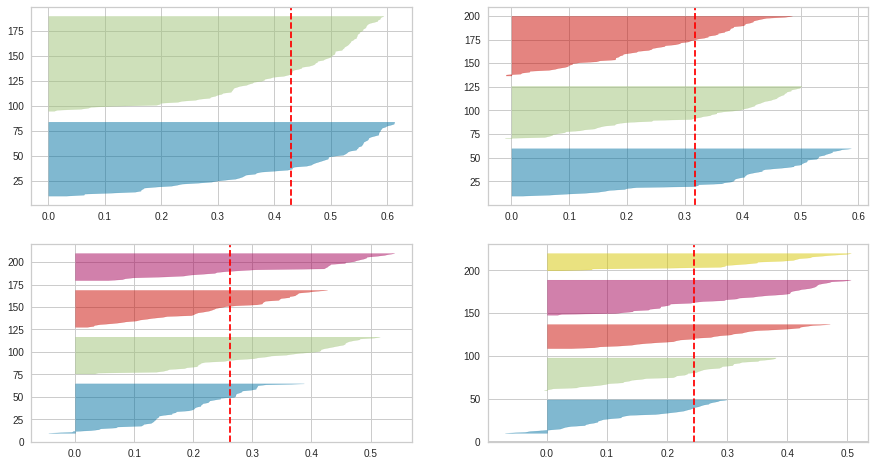

```python
from yellowbrick.cluster import SilhouetteVisualizer

fig, ax = plt.subplots(2, 2, figsize=(15,8))
for i in [2, 3,4,5]:
    '''
    Create KMeans instance for different number of clusters
    '''
    km = KMeans(n_clusters=i, init='k-means++', n_init=10, max_iter=100, random_state=10)
    q, mod = divmod(i, 2)
    '''
    Create SilhouetteVisualizer instance with KMeans instance
    Fit the visualizer
    '''
    visualizer = SilhouetteVisualizer(km, colors='yellowbrick', ax=ax[q-1][mod])
    visualizer.fit(world_df.iloc[:,0:16])
```

The silhouette plot for n_clusters=3 is comparatively low than n_clusters=2 and also the thickness and size of clusters are uneven in n_clusters=3 and more accurate and sensible in n_clusters=2. So, we can consider 2 clusters for the given data for kmeans. (k=2)

```python
means = []
interia = []
for i in range(1, 10):

    kmeans = KMeans(n_clusters=i)
    kmeans.fit(world_df.iloc[:,0:16])
    interia.append(kmeans.inertia_)
    means.append(i)

    print('SSE Data: '+ str(kmeans.inertia_))
```

```
SSE Data: 123.17922459884613
SSE Data: 57.578654201991924
SSE Data: 43.65779910665317
SSE Data: 36.691058777134714
SSE Data: 33.31696670610668
SSE Data: 30.884894939407452
SSE Data: 28.914439502435712
SSE Data: 27.45106098006058
SSE Data: 26.376955665935697
```

**Elbow method**

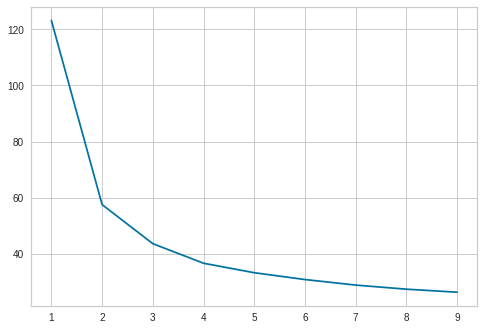

```python
sns.lineplot( x = means, y = interia,data=kmeans.inertia_)
```

```python
kmeans=KMeans(n_clusters=2)
kmeans.fit(world_df.iloc[:,0:16])
```

```
KMeans(n_clusters=2)
```

```python
kmeans.labels_
```

```
array([1, 1, 1, 1, 1, 1, 1, 1, 1, 1, 1, 1, 1, 1, 0, 1, 1, 1, 1, 1, 1, 1,
       1, 1, 1, 1, 1, 1, 1, 1, 0, 0, 1, 1, 1, 1, 1, 1, 1, 0, 1, 1, 1, 1,
       1, 1, 0, 1, 1, 1, 0, 0, 1, 1, 0, 1, 0, 0, 1, 1, 0, 0, 0, 1, 1, 0,
       1, 1, 1, 1, 0, 0, 1, 0, 1, 1, 0, 0, 0, 0, 0, 0, 0, 0, 0, 0, 0, 0,
       0, 0, 0, 0, 0, 0, 0, 0, 0, 0, 0, 0, 0, 0, 0, 0, 0, 0, 0, 0, 0, 0,
       0, 0, 0, 0, 0, 0, 0, 0, 0, 0, 1, 0, 0, 0, 0, 0, 0, 0, 0, 1, 0, 0,
       1, 1, 0, 1, 1, 1, 1, 0, 0, 0, 0, 1, 1, 0, 0, 0, 0, 0, 0, 0, 0, 0,
       1, 1, 1, 1, 0, 0, 1, 0, 1, 0, 0, 0, 0, 0, 0, 0, 0], dtype=int32)
```

```python
world_df['KMeans_pred']=kmeans.labels_
```

```python
world_df.head()
```

|  | Birth Rate | Business Tax Rate | Days to Start Business | GDP | Health Exp % GDP | Health Exp/Capita | Hours to do Tax | Infant Mortality Rate | Internet Usage | Life Expectancy Female | Life Expectancy Male | Mobile Phone Usage | Population 0-14 | Population 15-64 | Population 65+ | Population Urban | Region | Country | KMeans_pred |
| --- | --- | --- | --- | --- | --- | --- | --- | --- | --- | --- | --- | --- | --- | --- | --- | --- | --- | --- | --- |
| 0 | 0.404762 | 0.192319 | 0.034632 | 0.012804 | 0.158228 | 0.022332 | 0.169629 | 0.190909 | 0.111111 | 0.658537 | 0.666667 | 0.45 | 0.381471 | 0.539267 | 0.188034 | 0.650933 | Africa | Algeria | 1 |
| 1 | 0.904762 | 0.132144 | 0.093795 | 0.006692 | 0.094937 | 0.016774 | 0.104328 | 0.954545 | 0.111111 | 0.195122 | 0.138889 | 0.25 | 0.940054 | 0.062827 | 0.089744 | 0.351262 | Africa | Angola | 1 |
| 2 | 0.690476 | 0.173874 | 0.040404 | 0.000459 | 0.164557 | 0.002223 | 0.099691 | 0.527273 | 0.000000 | 0.365854 | 0.361111 | 0.40 | 0.817439 | 0.167539 | 0.111111 | 0.366630 | Africa | Benin | 1 |
| 3 | 0.380952 | 0.033565 | 0.085137 | 0.000973 | 0.208861 | 0.039612 | 0.054096 | 0.336364 | 0.111111 | 0.024390 | 0.055556 | 0.75 | 0.566757 | 0.392670 | 0.136752 | 0.522503 | Africa | Botswana | 1 |
| 4 | 0.809524 | 0.106138 | 0.017316 | 0.000658 | 0.284810 | 0.002728 | 0.099691 | 0.600000 | 0.000000 | 0.268293 | 0.277778 | 0.25 | 0.888283 | 0.109948 | 0.094017 | 0.193194 | Africa | Burkina Faso | 1 |

**Hierarchical Clustering**

```python
import scipy.cluster.hierarchy as sch
from sklearn.cluster import AgglomerativeClustering
```

```python
range_n_clusters = [2, 3, 4, 5, 6]

for n in range(2, 7):

    clusterer = AgglomerativeClustering(n_clusters=n)
    cluster_labels = clusterer.fit_predict(world_df.iloc[:,0:16])

    silhouette_avg = silhouette_score(world_df.iloc[:,0:16], cluster_labels)
    print("For n_clusters =", n, "The average silhouette_score is :", silhouette_avg)
```

```
For n_clusters = 2 The average silhouette_score is : 0.4176400922367597
For n_clusters = 3 The average silhouette_score is : 0.2908319647648453
For n_clusters = 4 The average silhouette_score is : 0.258764324872144
For n_clusters = 5 The average silhouette_score is : 0.23458755584371851
For n_clusters = 6 The average silhouette_score is : 0.22014494900150886
```

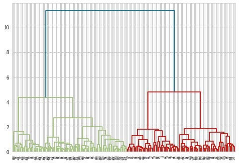

```python
dendrogram=sch.dendrogram(sch.linkage(world_df.iloc[:,0:16],method='ward'))
```

```python
hierarchical_1 = AgglomerativeClustering(n_clusters=2).fit(world_df.iloc[:,0:16])
hierarchical_1.labels_
```

```
array([0, 0, 0, 0, 0, 0, 0, 0, 0, 0, 0, 0, 0, 0, 0, 0, 0, 0, 0, 0, 0, 0,
       0, 0, 0, 0, 0, 0, 0, 0, 1, 1, 0, 0, 0, 0, 0, 0, 0, 1, 0, 0, 0, 0,
       0, 0, 1, 0, 0, 0, 1, 1, 0, 0, 1, 0, 1, 1, 0, 0, 1, 1, 1, 0, 0, 1,
       0, 0, 0, 0, 1, 0, 0, 1, 0, 0, 1, 1, 1, 1, 1, 1, 1, 1, 1, 1, 1, 1,
       1, 1, 1, 1, 1, 1, 1, 1, 1, 1, 1, 1, 1, 1, 1, 1, 1, 1, 1, 1, 1, 1,
       1, 1, 1, 1, 1, 1, 1, 1, 1, 0, 0, 1, 0, 1, 1, 1, 1, 1, 1, 0, 1, 0,
       0, 0, 1, 0, 0, 0, 0, 1, 1, 1, 1, 0, 0, 1, 1, 1, 1, 1, 1, 0, 0, 1,
       0, 0, 0, 0, 1, 1, 0, 1, 0, 1, 1, 1, 0, 1, 1, 1, 1])
```

```python
world_df['Hier_pred'] = hierarchical_1.labels_
```

```python
world_df.head()
```

|  | Birth Rate | Business Tax Rate | Days to Start Business | GDP | Health Exp % GDP | Health Exp/Capita | Hours to do Tax | Infant Mortality Rate | Internet Usage | Life Expectancy Female | Life Expectancy Male | Mobile Phone Usage | Population 0-14 | Population 15-64 | Population 65+ | Population Urban | Region | Country | KMeans_pred | Hier_pred |
| --- | --- | --- | --- | --- | --- | --- | --- | --- | --- | --- | --- | --- | --- | --- | --- | --- | --- | --- | --- | --- |
| 0 | 0.404762 | 0.192319 | 0.034632 | 0.012804 | 0.158228 | 0.022332 | 0.169629 | 0.190909 | 0.111111 | 0.658537 | 0.666667 | 0.45 | 0.381471 | 0.539267 | 0.188034 | 0.650933 | Africa | Algeria | 1 | 0 |
| 1 | 0.904762 | 0.132144 | 0.093795 | 0.006692 | 0.094937 | 0.016774 | 0.104328 | 0.954545 | 0.111111 | 0.195122 | 0.138889 | 0.25 | 0.940054 | 0.062827 | 0.089744 | 0.351262 | Africa | Angola | 1 | 0 |
| 2 | 0.690476 | 0.173874 | 0.040404 | 0.000459 | 0.164557 | 0.002223 | 0.099691 | 0.527273 | 0.000000 | 0.365854 | 0.361111 | 0.40 | 0.817439 | 0.167539 | 0.111111 | 0.366630 | Africa | Benin | 1 | 0 |
| 3 | 0.380952 | 0.033565 | 0.085137 | 0.000973 | 0.208861 | 0.039612 | 0.054096 | 0.336364 | 0.111111 | 0.024390 | 0.055556 | 0.75 | 0.566757 | 0.392670 | 0.136752 | 0.522503 | Africa | Botswana | 1 | 0 |
| 4 | 0.809524 | 0.106138 | 0.017316 | 0.000658 | 0.284810 | 0.002728 | 0.099691 | 0.600000 | 0.000000 | 0.268293 | 0.277778 | 0.25 | 0.888283 | 0.109948 | 0.094017 | 0.193194 | Africa | Burkina Faso | 1 | 0 |

**Count of countries in each cluster for KMeans and Hierarchical**

```python
a = world_df.groupby(hierarchical_1.labels_)['Country'].nunique()
print("For Hierarchical Clustring")
print(a)
print('\n')
b = world_df.groupby(kmeans.labels_)['Country'].nunique()
print("For KMeans Clustring")
print(b)
```

```
For Hierarchical Clustring
0    83
1    88
Name: Country, dtype: int64


For KMeans Clustring
0    96
1    75
Name: Country, dtype: int64
```

**Calculating dunn index**

```python
#Formula for dunn index:
#  DI m =min    δ(Ci,Cj )   /   max   ∆k
#       1⩽i<j⩽m                 1⩽k⩽m
#      Ci,Cj are centriods of different clusters
```

```python
!pip install validclust
```

```python
from validclust import dunn
from sklearn.metrics import pairwise_distances
dist_df = pairwise_distances(world_df.iloc[:,0:16])
dunn_df = dunn(dist_df,kmeans.labels_)
print('Dunn index: '+ str(dunn_df))
```

```
Dunn index: 0.12192108167876109
```

A higher Dunn Index will indicate well-separated clusters, while a lower index will indicate less compact or less well-separated clusters.

```python
dist_df
```

```
array([[0.        , 1.42139937, 0.89972353, ..., 1.79606364, 0.86518563,
        0.51927041],
       [1.42139937, 0.        , 0.61502934, ..., 2.5767265 , 1.97510997,
        1.65428449],
       [0.89972353, 0.61502934, 0.        , ..., 2.24033401, 1.52591842,
        1.19975251],
       ...,
       [1.79606364, 2.5767265 , 2.24033401, ..., 0.        , 1.41773611,
        1.66458532],
       [0.86518563, 1.97510997, 1.52591842, ..., 1.41773611, 0.        ,
        0.63119057],
       [0.51927041, 1.65428449, 1.19975251, ..., 1.66458532, 0.63119057,
        0.        ]])
```

**CH Ratio**

```python
#    Formula of CH ratio:
#    SSE(Ci)= Σ   (d((ci,x)*(ci,x)))
#            x∈Ci

#    x is an example in the cluster and ci is a centroid
#         k
#    SSB= Σ mi*d(ci,c)(ci,c)
#         i=1
#     ci is the mean of ith cluster and c is overall mean

#CH ratio=(SSBm/M-1)/(SSEm/M)
#M are the number of clusters
```

```python
print('CH Ratio: '+ str(metrics.calinski_harabasz_score(world_df.iloc[:,0:16], kmeans.labels_)))
print('CH Ratio: '+ str(metrics.calinski_harabasz_score(world_df.iloc[:,0:16], hierarchical_1.labels_)))
```

```
CH Ratio: 192.54525050508803
CH Ratio: 184.87996192103543
```

We can observe that KMeans has more CH ratio and hence it is more better than hierarchical for this data.

**Similar countries together**

```python
X=world_df.iloc[:,[17,18]].values
X
```

```
array([['Algeria', 1],
       ['Angola', 1],
       ['Benin', 1],
       ['Botswana', 1],
       ['Burkina Faso', 1],
       ['Burundi', 1],
       ['Cameroon', 1],
       ['Central African Republic', 1],
       ['Chad', 1],
       ['Comoros', 1],
       ['Congo, Dem. Rep.', 1],
       ['Congo, Rep.', 1],
       ["Cote d'Ivoire", 1],
       ['Djibouti', 1],
       ['Egypt, Arab Rep.', 0],
       ['Equatorial Guinea', 1],
       ['Eritrea', 1],
       ['Ethiopia', 1],
       ['Gabon', 1],
       ['Gambia, The', 1],
       ['Ghana', 1],
       ['Guinea', 1],
       ['Guinea-Bissau', 1],
       ['Kenya', 1],
       ['Lesotho', 1],
       ['Liberia', 1],
       ['Madagascar', 1],
       ['Malawi', 1],
       ['Mali', 1],
       ['Mauritania', 1],
       ['Mauritius', 0],
       ['Morocco', 0],
       ['Mozambique', 1],
       ['Namibia', 1],
       ['Niger', 1],
       ['Nigeria', 1],
       ['Rwanda', 1],
       ['Sao Tome and Principe', 1],
       ['Senegal', 1],
       ['Seychelles', 0],
```

[output cut: 116 more lines]

```
       ['Haiti', 1],
       ['Honduras', 1],
       ['Jamaica', 0],
       ['Mexico', 0],
       ['Nicaragua', 1],
       ['Panama', 0],
       ['Paraguay', 1],
       ['Peru', 0],
       ['St. Lucia', 0],
       ['St. Vincent and the Grenadines', 0],
       ['Suriname', 0],
       ['Trinidad and Tobago', 0],
       ['United States', 0],
       ['Uruguay', 0],
       ['Venezuela, RB', 0]], dtype=object)
```

```python
a = world_df[['Country', 'KMeans_pred']]
a.sort_values(by=['KMeans_pred'], inplace=True)
print(a)
```

```
            Country  KMeans_pred
96   Czech Republic            0
114  Macedonia, FYR            0
115           Malta            0
116         Moldova            0
118      Montenegro            0
..              ...          ...
41     Sierra Leone            1
43     South Africa            1
45            Sudan            1
35            Niger            1
0           Algeria            1

[171 rows x 2 columns]
```

**Scatterplot: Infant Mortality Rate vs GDP**

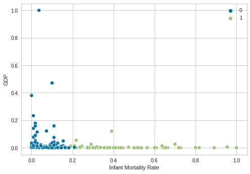

```python
sns.scatterplot(x = world_df['Infant Mortality Rate'], y = world_df['GDP'], data= world_df.iloc[:,0:16], hue=kmeans.labels_)
plt.xlabel('Infant Mortality Rate')
plt.ylabel('GDP')
```

We can observe that cluster 0's GDP is more for low infant mortality rate and as the infant mortality rate is increasing, there is no growth in GDP like in cluster 1.

**Scatter: plot Mobile Phone Usage vs GDP**

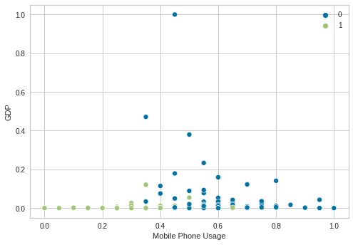

```python
sns.scatterplot(x = world_df['Mobile Phone Usage'], y = world_df['GDP'], data= world_df.iloc[:,0:16], hue=kmeans.labels_)
plt.xlabel('Mobile Phone Usage')
plt.ylabel('GDP')
```

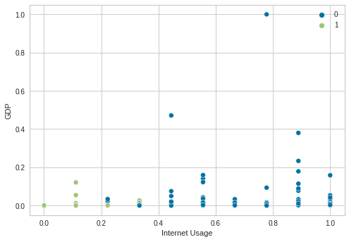

```python
sns.scatterplot(x = world_df['Internet Usage'], y = world_df['GDP'], data= world_df.iloc[:,0:16], hue=kmeans.labels_)
plt.xlabel('Internet Usage')
plt.ylabel('GDP')
```

With the usage of Internet, we can see that GDP also increases and so cluster 0 has higher GDP.